# R Notebook

# Chapter 9

## 9.9

```r
summarize_normal_normal(mean = 1000, sd = 2000, sigma = 10,
                        y_bar = 9000, n = 10000)
```

| model | mean | mode | var | sd |
| --- | --- | --- | --- | --- |
| prior | 1000 | 1000 | 4e+06 | 2e+03 |
| posterior | 9000 | 9000 | 1e-02 | 1e-01 |

```r
require(rstanarm)
model <- stan_glm(
  rides ~ humidity, data = bikes,
  family = gaussian,
  prior_PD = TRUE,
  prior_intercept = normal(1000, 2000, autoscale = TRUE),
  prior = normal(0, 10, autoscale = TRUE),
  prior_aux = exponential(1, autoscale = TRUE),
  chains = 5, iter = 8000, seed = 84735)
```

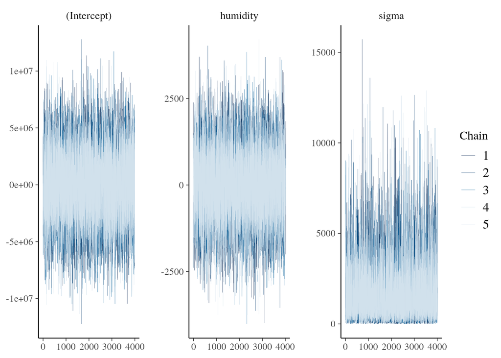

```r
require(bayesplot)

# Trace plots of parallel chains
mcmc_trace(model, size = .1)
```

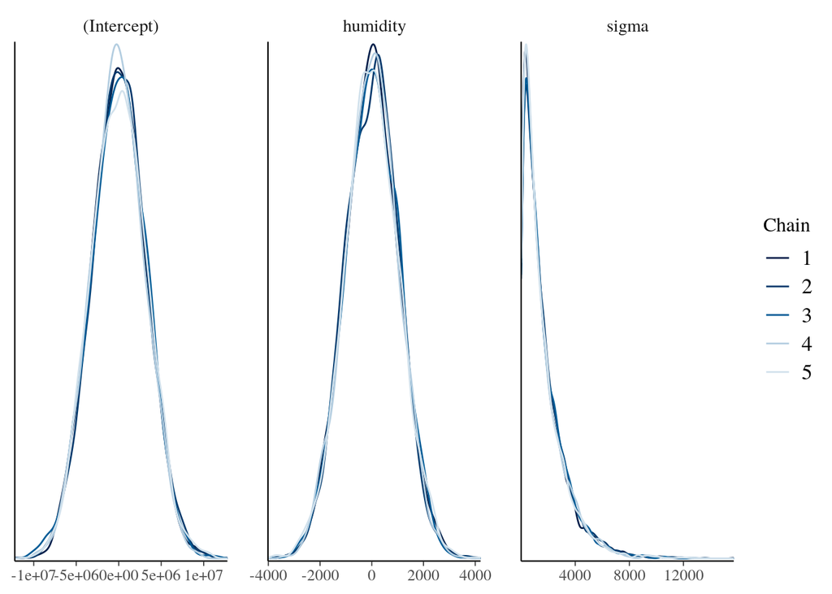

```r
# Density plots of parallel chains
mcmc_dens_overlay(model)
```

## 9.10

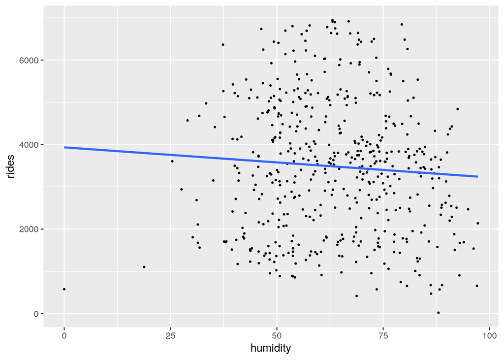

```r
# Load and plot data
data(bikes)
ggplot(bikes, aes(x = humidity, y = rides)) +
  geom_point(size = 0.5) +
  geom_smooth(method = "lm", se = FALSE)
```

The data is normally distributed enough; the points are fairly evenly distributed across the y-axis. Since it doesn’t form a trumpet-like shape, it could be fine for Normal regression.

## 9.11

```r
bike_model <- stan_glm(rides ~ humidity, data = bikes,
  family = gaussian,
  prior_PD = FALSE,
  prior_intercept = normal(1000, 2000, autoscale = TRUE),
  prior = normal(0, 10, autoscale = TRUE),
  prior_aux = exponential(1, autoscale = TRUE),
  chains = 5, iter = 4000*2, seed = 84735)
# Effective sample size ratio
neff_ratio(bike_model)
```

```
## (Intercept)    humidity       sigma
##     0.99525     0.99270     0.96705
```

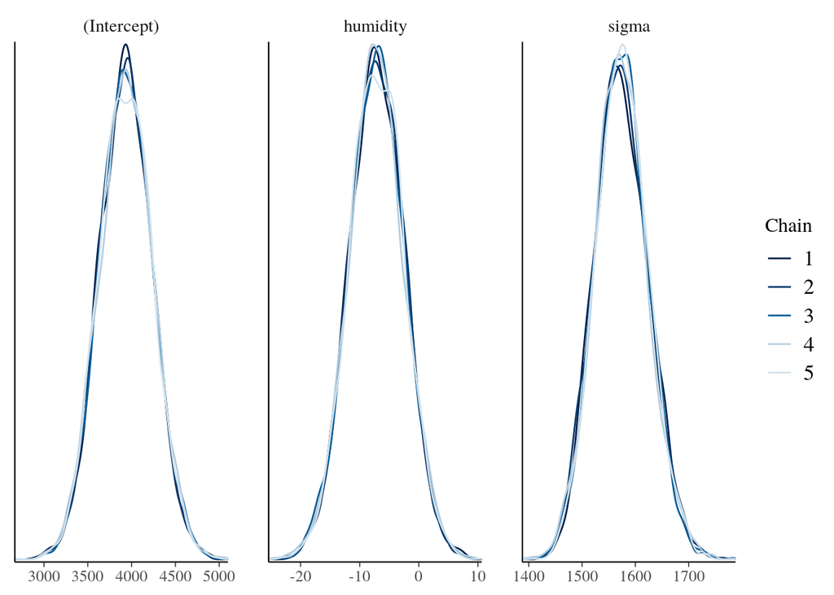

```r
# Density plots of parallel chains
mcmc_dens_overlay(bike_model)
```

Given the results above, we can trust these simulation results.

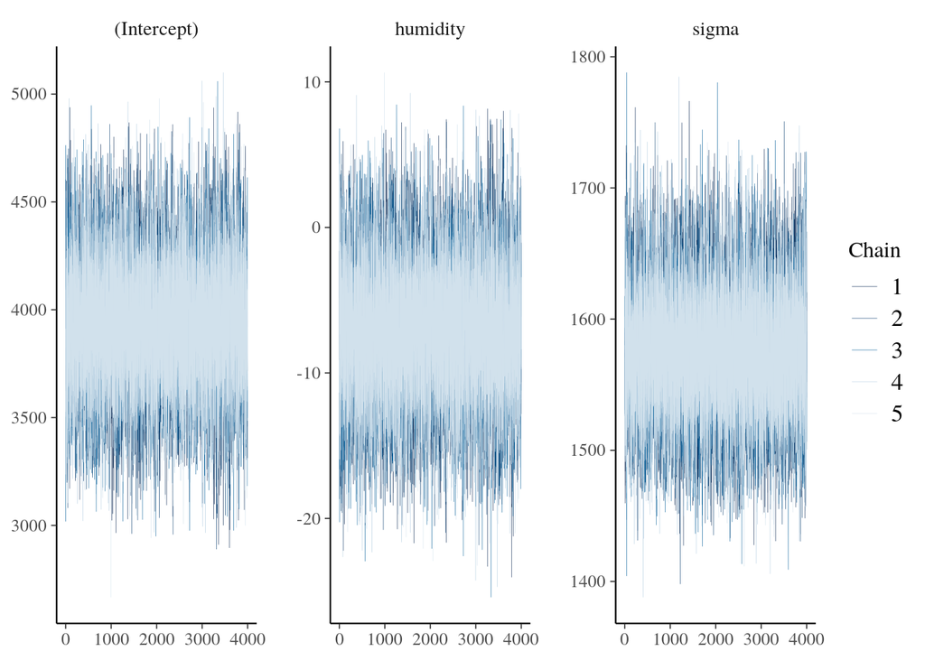

```r
# Trace plots of parallel chains
mcmc_trace(bike_model, size = .1)
```

The sigma is more centered than 9.9’s and the scales are much different.

## 9.12

```r
tidy(bike_model, effects = c("fixed", "aux"),
     conf.int = TRUE, conf.level = 0.95)
```

| term | estimate | std.error | conf.low | conf.high |
| --- | --- | --- | --- | --- |
| (Intercept) | 3935.315289 | 303.399737 | 3342.13443 | 4534.172490 |
| humidity | -7.128445 | 4.635609 | -16.16035 | 1.899641 |
| sigma | 1573.039578 | 49.743937 | 1479.80167 | 1675.860252 |
| mean_PPD | 3482.972419 | 100.493682 | 3283.52514 | 3677.743889 |

The CI represents the uncertainty in the relationship.
$$\beta_1$$
(-16.16035,1.899641) indicates that this slope could range anywhere between about -16 and 2.

I would say that we have alright posterior evidence that there’s a negative association between ridership and humidity. The standard error is low enough for it to carry some weight, but not low enough for there to be very certain evidence to their relationship. However, the CI is a small range, so that does help the credibility of the evidence of their relationship.

## 9.16

```r
summary(penguins_bayes)
```

```
##       species          island         year      bill_length_mm  bill_depth_mm
##  Adelie   :152   Biscoe   :168   Min.   :2007   Min.   :32.10   Min.   :13.10
##  Chinstrap: 68   Dream    :124   1st Qu.:2007   1st Qu.:39.23   1st Qu.:15.60
##  Gentoo   :124   Torgersen: 52   Median :2008   Median :44.45   Median :17.30
##                                  Mean   :2008   Mean   :43.92   Mean   :17.15
##                                  3rd Qu.:2009   3rd Qu.:48.50   3rd Qu.:18.70
##                                  Max.   :2009   Max.   :59.60   Max.   :21.50
##                                                 NA's   :2       NA's   :2
##  flipper_length_mm  body_mass_g   above_average_weight     sex
##  Min.   :172.0     Min.   :2700   0   :193             female:165
##  1st Qu.:190.0     1st Qu.:3550   1   :149             male  :168
##  Median :197.0     Median :4050   NA's:  2             NA's  : 11
##  Mean   :200.9     Mean   :4202
##  3rd Qu.:213.0     3rd Qu.:4750
##  Max.   :231.0     Max.   :6300
##  NA's   :2         NA's   :2
```

```r
penguins_model <- stan_glm(flipper_length_mm ~ bill_length_mm, data = penguins_bayes,
                       family = gaussian,
                       prior_PD = TRUE,
                       prior_intercept = normal(43.92, 11.82),
                       prior = normal(200.9, 28.9),
                       prior_aux = exponential(0.0008),
                       chains = 4, iter = 10000*2, seed = 84735)
prior_summary(penguins_model)
```

```
## Priors for model 'penguins_model'
## ------
## Intercept (after predictors centered)
##  ~ normal(location = 44, scale = 12)
##
## Coefficients
##  ~ normal(location = 201, scale = 29)
##
## Auxiliary (sigma)
##  ~ exponential(rate = 8e-04)
## ------
## See help('prior_summary.stanreg') for more details
```

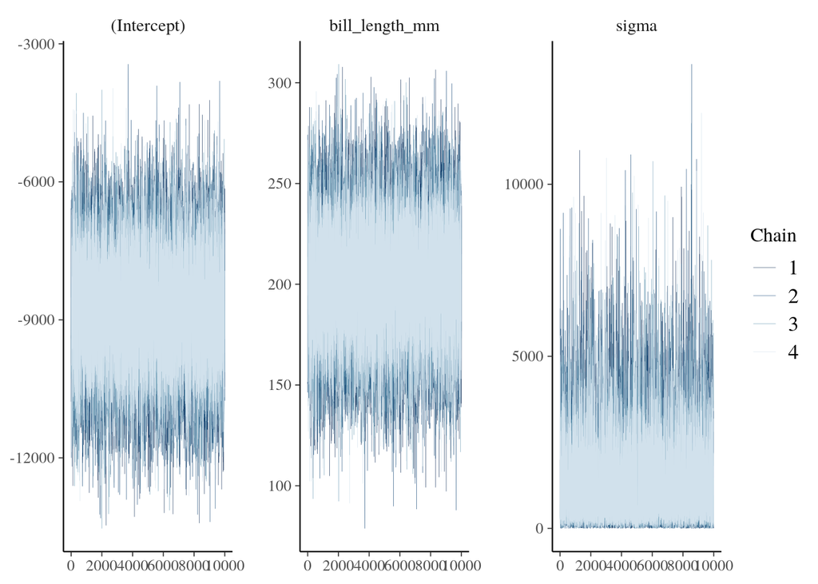

```r
# Trace plots of parallel chains
mcmc_trace(penguins_model, size = 0.1)
```

## 9.17

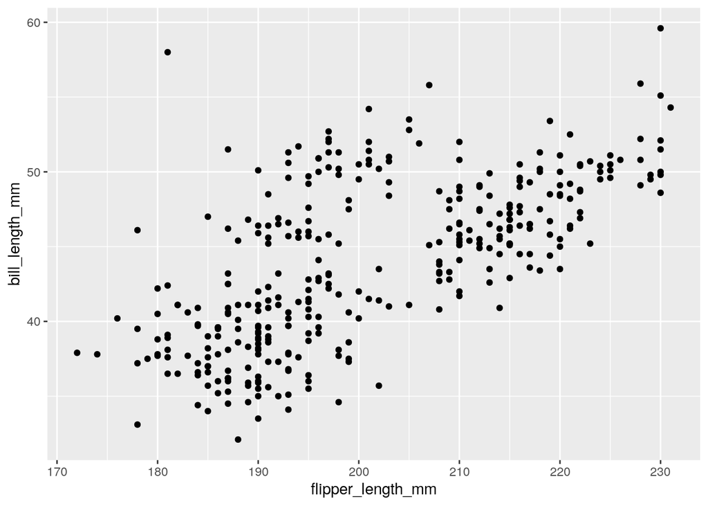

```r
penguins_bayes |>
  ggplot(aes(x = flipper_length_mm, y = bill_length_mm)) +
  geom_point()
```

There appears to be a positive linear relationship between flipper and bill length.

It meets the conditions for a simple normal regression model. It has linearity on the plot above. If it also has independent observations and is normally distributed on a fitted vs resids plot, we can use a normal model.

## 9.18

```r
penguins_post_model <- stan_glm(flipper_length_mm ~ bill_length_mm, data = penguins_bayes,
                       family = gaussian,
                       prior_intercept = normal(43.92, 11.82),
                       prior = normal(200.9, 28.9),
                       prior_aux = exponential(0.0008),
                       chains = 4, iter = 10000*2, seed = 84735)
```

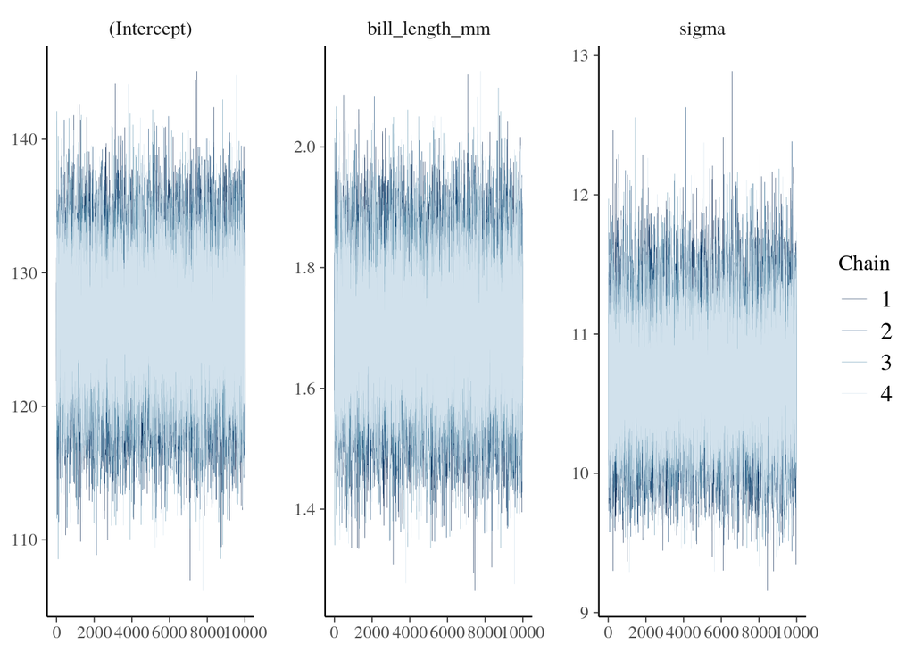

```r
# Trace plots of parallel chains
mcmc_trace(penguins_post_model, size = 0.1)
```

```r
tidy(penguins_post_model, conf.int = TRUE, conf.level = 0.90)
```

| term | estimate | std.error | conf.low | conf.high |
| --- | --- | --- | --- | --- |
| (Intercept) | 126.213356 | 4.6715939 | 118.480438 | 133.859180 |
| bill_length_mm | 1.692387 | 0.1057911 | 1.519342 | 1.867017 |

There is a 90% probability that the true bill_length_mm lies within .1.5-.1.9.

# Chapter 10

## 10.7

```r
problem7_data <-
  tibble(
    x = c(12,10,4,8,6),
    y = c(20,17,4,11,9)
  )
```

$$

y=mx+b \

$$

```r
problem7_data |>
  mutate(y_hat=-1.8+2.1*x,
         y_model=-1.8+2.1*x+rnorm(5,0,0.8),
         y_model2=rnorm(5,-1.8+2.1*x,0.8)
        )
```

| x | y | y_hat | y_model | y_model2 |
| --- | --- | --- | --- | --- |
| 12 | 20 | 23.4 | 23.425727 | 24.197196 |
| 10 | 17 | 19.2 | 19.406952 | 18.963686 |
| 4 | 4 | 6.6 | 6.184008 | 6.385534 |
| 8 | 11 | 15.0 | 16.119690 | 15.579112 |
| 6 | 9 | 10.8 | 11.122283 | 11.319058 |

## 10.13

```r
head(coffee_ratings)
```

| owner | farm_name | mill | in_country_partner | country_of_origin | altitude_low_meters | altitude_high_meters | altitude_mean_meters | number_of_bags | bag_weight | species | variety | processing_method | aroma | flavor | aftertaste | acidity | body | balance | uniformity | clean_cup | sweetness | moisture | category_one_defects | category_two_defects | color | total_cup_points |
| --- | --- | --- | --- | --- | --- | --- | --- | --- | --- | --- | --- | --- | --- | --- | --- | --- | --- | --- | --- | --- | --- | --- | --- | --- | --- | --- |
| metad plc | metad plc | metad plc | METAD Agricultural Development plc | Ethiopia | 1950 | 2200 | 2075 | 300 | 60 kg | Arabica | NA | Washed / Wet | 8.67 | 8.83 | 8.67 | 8.75 | 8.50 | 8.42 | 10 | 10 | 10 | 0.12 | 0 | 0 | Green | 90.58 |
| metad plc | metad plc | metad plc | METAD Agricultural Development plc | Ethiopia | 1950 | 2200 | 2075 | 300 | 60 kg | Arabica | Other | Washed / Wet | 8.75 | 8.67 | 8.50 | 8.58 | 8.42 | 8.42 | 10 | 10 | 10 | 0.12 | 0 | 1 | Green | 89.92 |
| grounds for health admin | san marcos barrancas "san cristobal cuch | NA | Specialty Coffee Association | Guatemala | 1600 | 1800 | 1700 | 5 | 1 | Arabica | Bourbon | NA | 8.42 | 8.50 | 8.42 | 8.42 | 8.33 | 8.42 | 10 | 10 | 10 | 0.00 | 0 | 0 | NA | 89.75 |
| yidnekachew dabessa | yidnekachew dabessa coffee plantation | wolensu | METAD Agricultural Development plc | Ethiopia | 1800 | 2200 | 2000 | 320 | 60 kg | Arabica | NA | Natural / Dry | 8.17 | 8.58 | 8.42 | 8.42 | 8.50 | 8.25 | 10 | 10 | 10 | 0.11 | 0 | 2 | Green | 89.00 |
| metad plc | metad plc | metad plc | METAD Agricultural Development plc | Ethiopia | 1950 | 2200 | 2075 | 300 | 60 kg | Arabica | Other | Washed / Wet | 8.25 | 8.50 | 8.25 | 8.50 | 8.42 | 8.33 | 10 | 10 | 10 | 0.12 | 0 | 2 | Green | 88.83 |
| ji-ae ahn | NA | NA | Specialty Coffee Institute of Asia | Brazil | NA | NA | NA | 100 | 30 kg | Arabica | NA | Natural / Dry | 8.58 | 8.42 | 8.42 | 8.50 | 8.25 | 8.33 | 10 | 10 | 10 | 0.11 | 0 | 1 | Bluish-Green | 88.83 |

It likely violates the independence assumption due to aroma and aftertaste not being completely independent. Also, other variables come into play, such as sweetness, clean_cup, and acidity.

```r
set.seed(84735)
new_coffee <- coffee_ratings |>
  group_by(farm_name) |>
  sample_n(1) |>
  ungroup()
dim(new_coffee)
```

```
## [1] 572  27
```

## 10.14

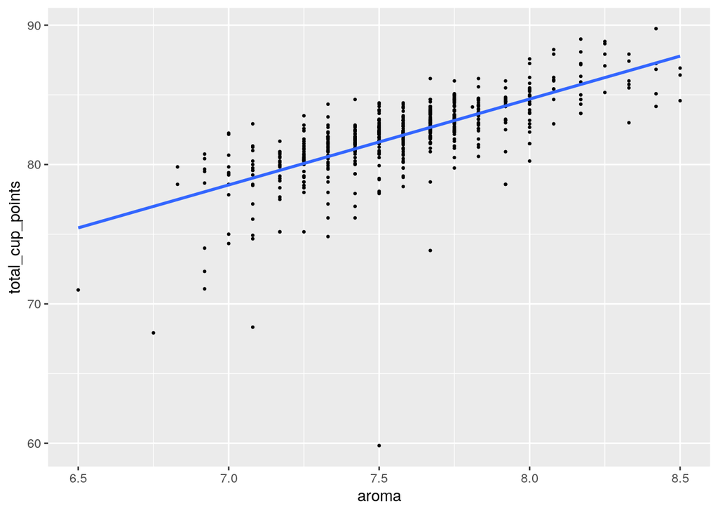

```r
ggplot(new_coffee, aes(x = aroma, y = total_cup_points)) +
  geom_point(size = 0.5) +
  geom_smooth(method = "lm", se = FALSE)
```

```r
summary(new_coffee)
```

```
##                             owner            farm_name
##  cqi taiwan icp cqi台灣合作夥伴: 44   -           :  1
##  juan luis alvarado romero     : 40   1           :  1
##  nucoffee                      : 26   200 farms   :  1
##  lin, che-hao krude 林哲豪     : 20   2000 farmers:  1
##  alfredo bojalil               : 14   2000 farms  :  1
##  (Other)                       :425   (Other)     :566
##  NA's                          :  3   NA's        :  1
##                                mill
##  beneficio ixchel                : 16
##  beneficio exportacafe agua santa:  9
##  mzuzu coffee coop union         :  9
##  zaragoza itundujia, oaxaca      :  9
##  agroindustrias unidas de mexico :  8
##  (Other)                         :435
##  NA's                            : 86
##                            in_country_partner
##  AMECAFE                            :156
##  Specialty Coffee Association       : 95
##  Blossom Valley International       : 52
##  Africa Fine Coffee Association     : 41
##  Asociacion Nacional Del Café       : 40
##  Uganda Coffee Development Authority: 30
##  (Other)                            :158
##                     country_of_origin altitude_low_meters altitude_high_meters
##  Mexico                      :170     Min.   :   12       Min.   :   12
##  Taiwan                      : 64     1st Qu.: 1015       1st Qu.: 1094
##  Brazil                      : 51     Median : 1250       Median : 1300
##  Guatemala                   : 50     Mean   : 1283       Mean   : 1327
##  Tanzania, United Republic Of: 34     3rd Qu.: 1500       3rd Qu.: 1569
##  Uganda                      : 29     Max.   :11000       Max.   :11000
##  (Other)                     :174     NA's   :36          NA's   :36
##  altitude_mean_meters number_of_bags     bag_weight     species
##  Min.   :   12        Min.   :   1.0   1 kg   :199   Arabica:558
##  1st Qu.: 1050        1st Qu.:  10.0   60 kg  :158   Robusta: 14
##  Median : 1270        Median :  38.5   69 kg  : 59
##  Mean   : 1305        Mean   : 108.6   2 kg   : 53
##  3rd Qu.: 1550        3rd Qu.: 250.0   30 kg  : 24
##  Max.   :11000        Max.   :1062.0   20 kg  : 10
##  NA's   :36                            (Other): 69
```

[output cut: 25 more lines]

```
##  Min.   :0.00000   Min.   : 0.0000      Min.   : 0.000       Blue-Green  : 44
##  1st Qu.:0.10000   1st Qu.: 0.0000      1st Qu.: 0.000       Bluish-Green: 43
##  Median :0.11000   Median : 0.0000      Median : 2.000       Green       :371
##  Mean   :0.09846   Mean   : 0.4161      Mean   : 3.932       None        : 37
##  3rd Qu.:0.12000   3rd Qu.: 0.0000      3rd Qu.: 5.000       NA's        : 77
##  Max.   :0.20000   Max.   :31.0000      Max.   :47.000
##
##  total_cup_points
##  Min.   :59.83
##  1st Qu.:80.92
##  Median :82.33
##  Mean   :82.10
##  3rd Qu.:83.58
##  Max.   :89.75
##
```

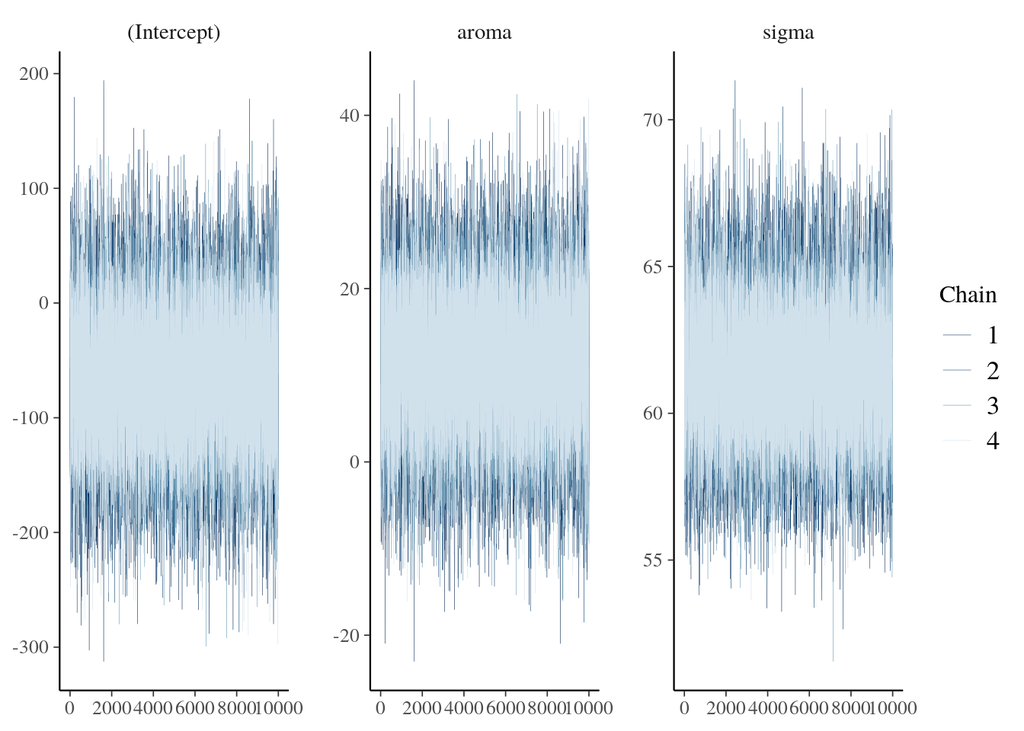

```r
coffee_model <- stan_glm(total_cup_points ~ aroma, data = new_coffee,
                       family = gaussian,
                       prior_intercept = normal(7.5, 1.2),
                       prior = normal(82.10, 30),
                       prior_aux = exponential(0.0008),
                       chains = 4, iter = 10000*2, seed = 84735)
mcmc_trace(coffee_model, size = 0.1)
```

```r
summary(coffee_model)
```

```
##
## Model Info:
##  function:     stan_glm
##  family:       gaussian [identity]
##  formula:      total_cup_points ~ aroma
##  algorithm:    sampling
##  sample:       40000 (posterior sample size)
##  priors:       see help('prior_summary')
##  observations: 572
##  predictors:   2
##
## Estimates:
##               mean   sd     10%    50%    90%
## (Intercept)  -65.6   60.2 -143.3  -65.3   11.5
## aroma         11.4    7.9    1.3   11.4   21.7
## sigma         61.4    2.3   58.5   61.4   64.3
##
## Fit Diagnostics:
##            mean   sd   10%   50%   90%
## mean_PPD 20.9    2.9 17.2  21.0  24.6
##
## The mean_ppd is the sample average posterior predictive distribution of the outcome variable (for details see help('summary.stanreg')).
##
## MCMC diagnostics
##               mcse Rhat n_eff
## (Intercept)   0.3  1.0  30160
## aroma         0.0  1.0  30212
## sigma         0.0  1.0  21874
## mean_PPD      0.0  1.0  33412
## log-posterior 0.0  1.0  16598
##
## For each parameter, mcse is Monte Carlo standard error, n_eff is a crude measure of effective sample size, and Rhat is the potential scale reduction factor on split chains (at convergence Rhat=1).
```

Aroma and rating are associated. The better a coffee’s aroma is, the rating is likely to be better as well.

## 10.15

```r
first_set <- head(coffee_model, 1)
first_set
```

```
## $coefficients
## (Intercept)       aroma
##   -65.27093    11.38488
```

```r
set.seed(84735)
one_simulation <- new_coffee |>
  mutate(mu = -65 + 11 * 11,
         simulated_coffee = rnorm(572, mean = mu, sd = 62))
```

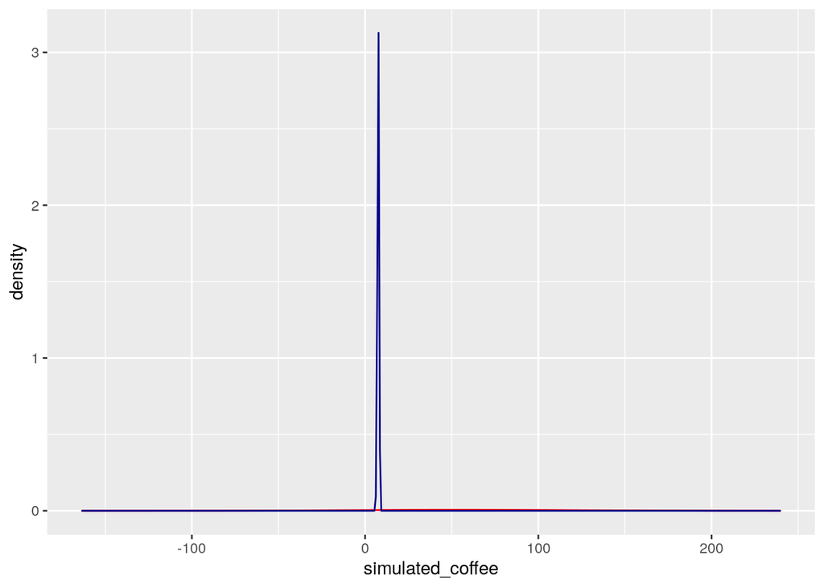

```r
ggplot(one_simulation, aes(x = simulated_coffee)) +
  geom_density(color = "red") +
  geom_density(aes(x = aroma), color = "darkblue")
```

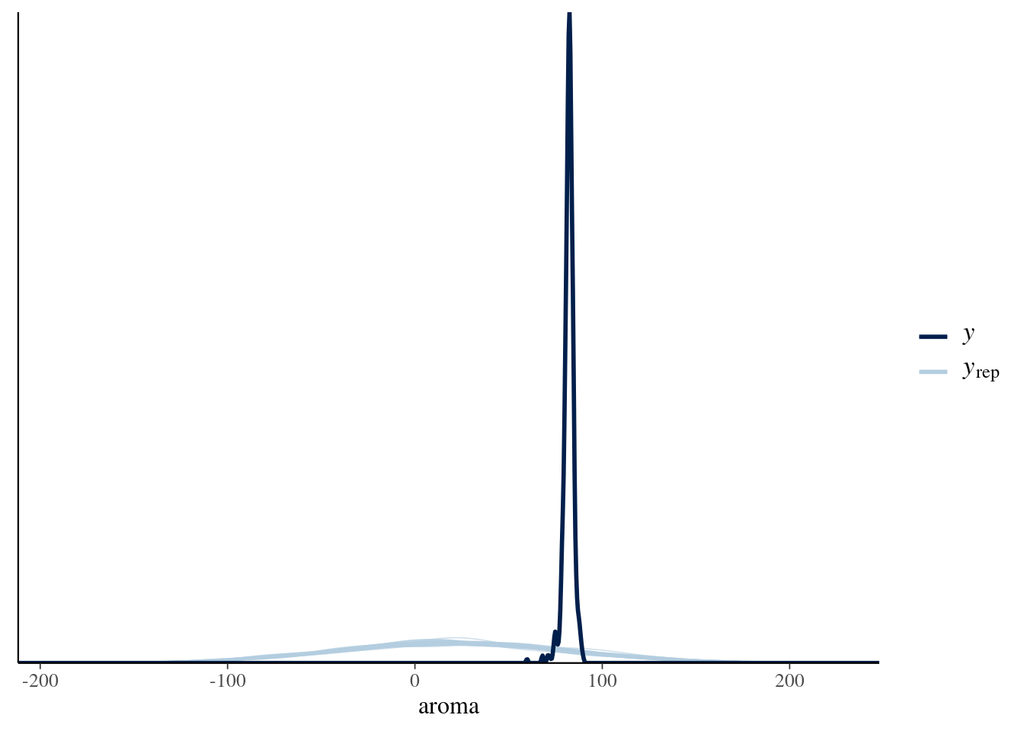

```r
pp_check(coffee_model, nreps = 50) +
  xlab("aroma")
```

Assumption 2 is that the relationship is linear.

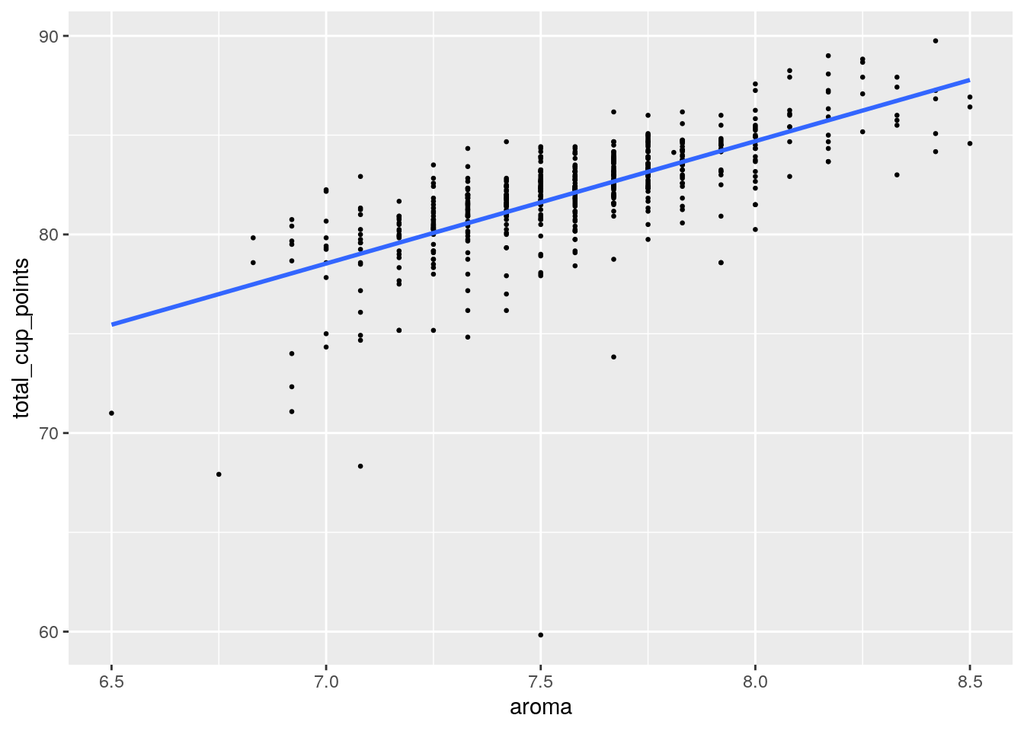

```r
ggplot(new_coffee, aes(x = aroma, y = total_cup_points)) +
  geom_point(size = 0.5) +
  geom_smooth(method = "lm", se = FALSE)
```

The relationship is basically linear. This passes this assumption.

Assumption 3 is that the variability in Y does not increase with X. As seen in the previous density plot, Y does not increase with X. It passes this assumption as well.

## 10.16

```r
set.seed(84735)
one_simulation2 <- new_coffee |>
  mutate(mu = -65 + 11 * 7.67,
         simulated_coffee = rnorm(572, mean = mu, sd = 62))
```

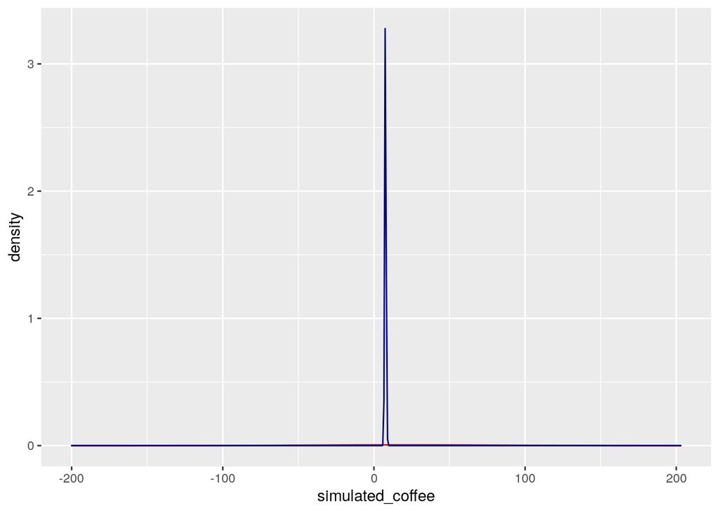

```r
ggplot(one_simulation2, aes(x = simulated_coffee)) +
  geom_density(color = "red") +
  geom_density(aes(x = aroma), color = "darkblue")
```

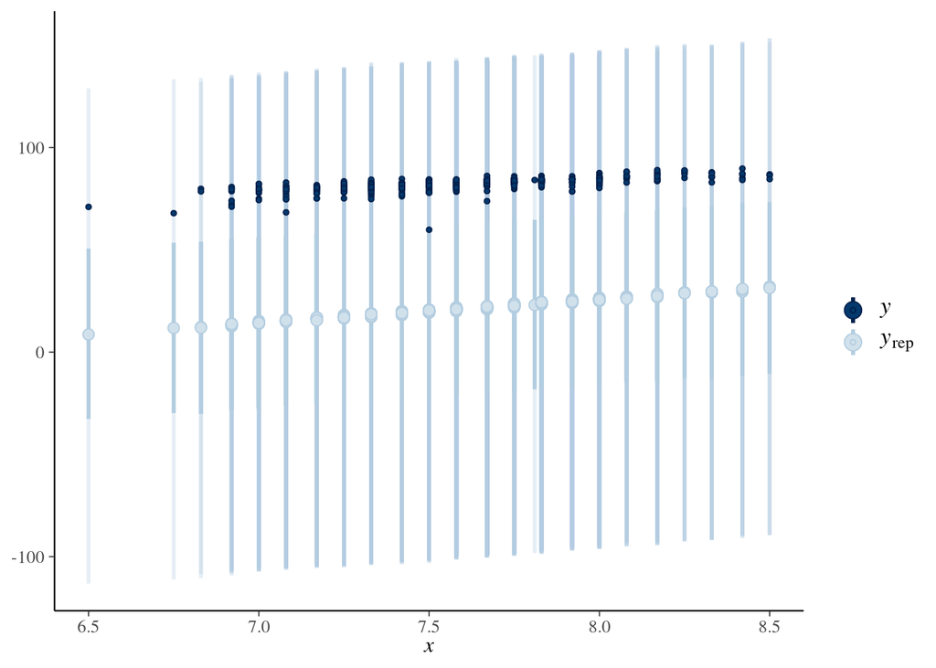

```r
set.seed(84735)
predictions <- posterior_predict(coffee_model, newdata = new_coffee)

ppc_intervals(new_coffee$total_cup_points, yrep = predictions, x = new_coffee$aroma,
              prob = 0.5, prob_outer = 0.95)
```

## 10.17

```r
set.seed(84735)
cv_procedure <- prediction_summary_cv(
  model = coffee_model, data = new_coffee, k = 10)
cv_procedure
```

```
## $folds
##    fold      mae mae_scaled  within_50 within_95
## 1     1 62.80766  0.9925783 0.00000000         1
## 2     2 62.53947  0.9884199 0.00000000         1
## 3     3 63.03013  0.9978984 0.00000000         1
## 4     4 63.69977  1.0094984 0.00000000         1
## 5     5 63.10568  0.9977054 0.01754386         1
## 6     6 63.55228  1.0022612 0.00000000         1
## 7     7 62.70761  0.9933662 0.00000000         1
## 8     8 63.49475  1.0062718 0.00000000         1
## 9     9 63.02339  0.9984953 0.00000000         1
## 10   10 62.36976  0.9885416 0.00000000         1
##
## $cv
##        mae mae_scaled   within_50 within_95
## 1 63.03305  0.9975036 0.001754386         1
```

MAE is the mean average error per fold, which measures the prediction quality. This measure displays the typical difference between the observed Y_i and their posterior predictive means.

MAE scaled is the mean average error that measures the typical number of standard deviations that the observed Y_i fall from their posterior predictive means. Its calculation is different from MAE due to dividing by standard deviation.

Within 50 measures the proportion of observed Y_i that are within their 50% posterior prediction interval.

Within 95 measures the proportion of observed Y_i that are within their 95% posterior prediction interval.

```r
set.seed(84735)
prediction_summary(coffee_model, data = new_coffee)
```

| mae | mae_scaled | within_50 | within_95 |
| --- | --- | --- | --- |
| 61.42186 | 0.9975367 | 0.001748252 | 1 |

The reported cross-validated MAE is verified given the information above from the 10 folds.

## 10.19

```r
coffee_model3 <- stan_glm(total_cup_points ~ aftertaste, data = new_coffee,
                       family = gaussian,
                       prior_intercept = normal(7.5, 1.2),
                       prior = normal(82.10, 30),
                       prior_aux = exponential(0.0008),
                       chains = 4, iter = 10000*2, seed = 84735)
```

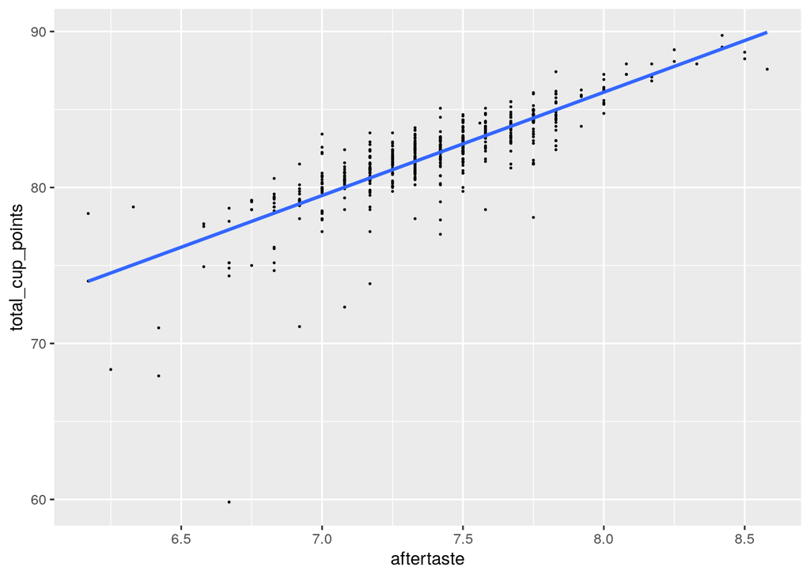

```r
ggplot(new_coffee, aes(y = total_cup_points, x = aftertaste)) +
  geom_point(size = 0.2) +
  geom_smooth(method = "lm", se = FALSE)
```

It passes the linearity assumption, #2.

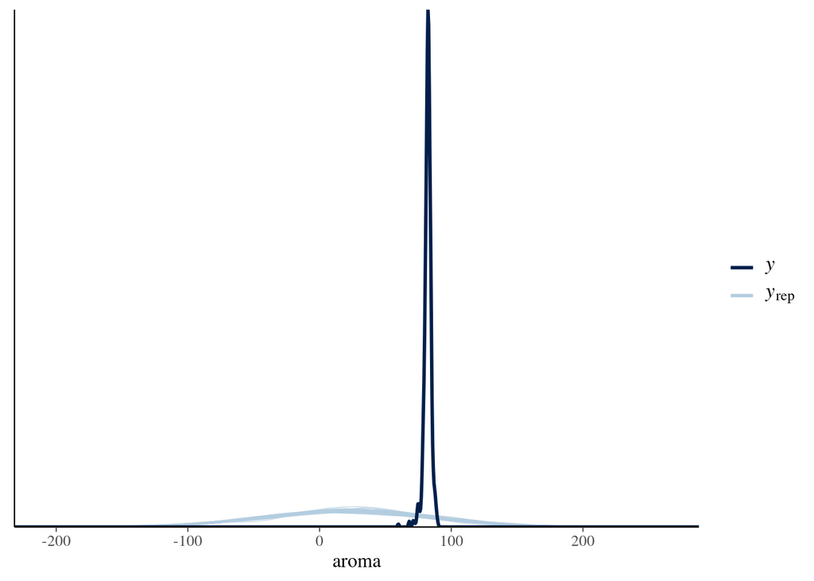

```r
pp_check(coffee_model3, nreps = 50) +
  xlab("aroma")
```

It passes assumption #3.

```r
set.seed(84735)
cv_procedure2 <- prediction_summary_cv(
  model = coffee_model3, data = new_coffee, k = 10)
cv_procedure2
```

```
## $folds
##    fold      mae mae_scaled within_50 within_95
## 1     1 62.50660  0.9878037         0         1
## 2     2 62.89712  0.9953129         0         1
## 3     3 62.94603  0.9988983         0         1
## 4     4 62.86463  0.9960967         0         1
## 5     5 62.34669  0.9866223         0         1
## 6     6 63.06410  1.0018723         0         1
## 7     7 62.90625  0.9975668         0         1
## 8     8 62.74828  0.9950811         0         1
## 9     9 63.21050  0.9927782         0         1
## 10   10 62.77930  0.9947936         0         1
##
## $cv
##        mae mae_scaled within_50 within_95
## 1 62.82695  0.9946826         0         1
```

Aftertaste has a stronger association with total_cup_points, so I would choose aftertaste.